# Classification of data

Sudev  
25 March, 2015

### Classification

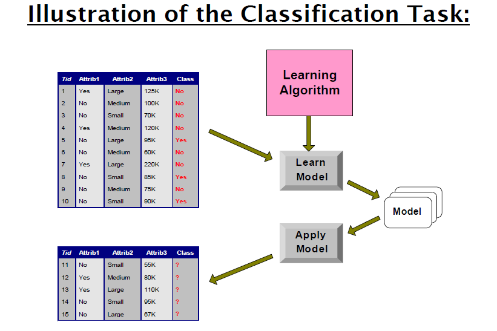

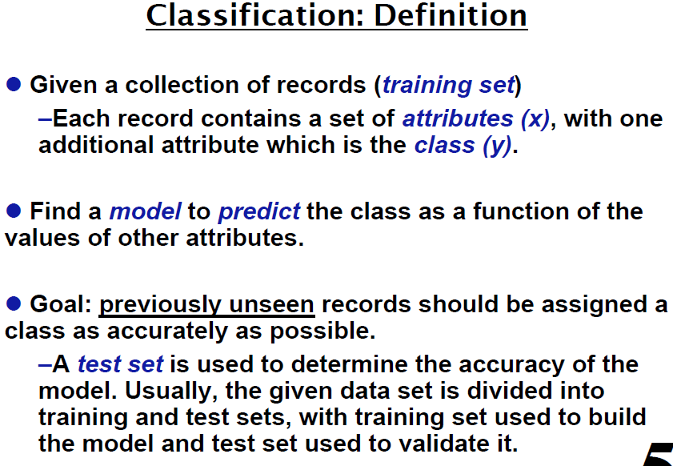

### Methods to classify

There are many [classification algorithms](http://en.wikipedia.org/wiki/Category:Classification_algorithms) now. We will start with something simple, [Decision trees](http://en.wikipedia.org/wiki/Decision_tree).

### How do we use the given decision tree with test data ?

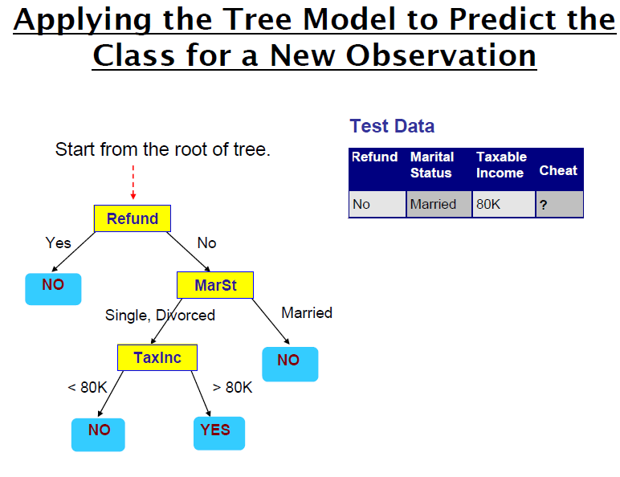

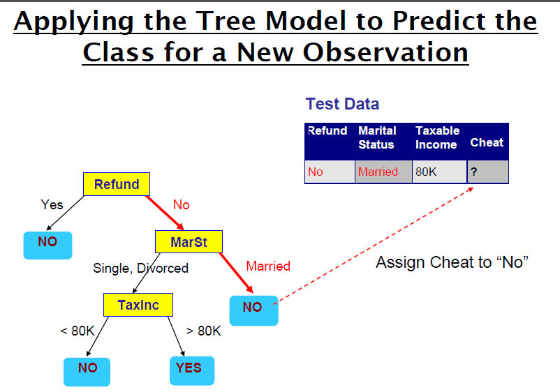

### Using R

```r
setwd("~/Desktop/Everything Else/R")
train=read.csv("assets/sonar_train.csv",header=FALSE)
# Number of fields in the dataset
length(train)
```

```
[1] 61
```

```r
# Number of observations in the dataset
nrow(train)
```

```
[1] 130
```

```r
# VERY IMPORTANT, you have to make the the thing to be predicted a factor so that prediction algorithm to work properly.
y=as.factor(train[,61])
x=train[,1:60]
```

Here `x` is the independent set of variables that we will use to predict the `y`.

### Model 1 (Default model)

You make a model in R using the rpart library.

```r
#install.packages("rpart")
library(rpart)

model1 = rpart(y ~., x)
```

Here `x` the dataset, `y` is the value that you want to predict. To make a model use the `rpart` function. So now we have the model in variable `model1`.

Also, we mention the fields/variables that we need to consider for modelling after the `~`, here we have given “`.`” which tells rpart to consider all the fields for prediction.

### Model 1 (Default model)

```r
# we use the function predict to output the predicted values using the model
model1TrainPreds = predict(model1, x, type="class")
# Sample predicted values
model1TrainPreds[1:5]
```

```
 1  2  3  4  5
-1  1 -1  1 -1
Levels: -1 1
```

### Model 1 (Default model)

Check how well it matches with actual data

```r
# A function to find percentage accuracy
percentageAccuracy = function(predVals, actualVals) {
  totalCorrect = sum(predVals == actualVals)
  per = totalCorrect / length(actualVals)
  per * 100
}
```

### Model 1 (Default model)

```r
# Call function with Predicted Values and Actual Values
percentageAccuracy(model1TrainPreds, y)
```

```
[1] 88.46154
```

Here we have calculated the percentage accuracy considering the same(training) data. Now lets see how well it does on a new data.

### Model 1 (Default model)

Now, use the test data set.

```r
test=read.csv("assets/sonar_test.csv",
               header=FALSE)
y_test=as.factor(test[,61])
x_test=test[,1:60]
model1TestPreds = predict(model1,x_test,type="class")
```

```r
# Finding the accuracy
percentageAccuracy(model1TestPreds, y_test)
```

```
[1] 69.23077
```

### Let's have a look at the model.

What happening under the hood ?

### Model 1 (Default model)

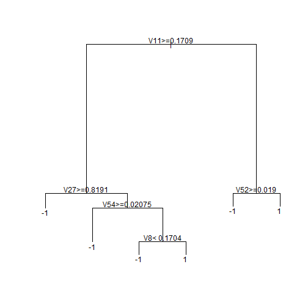

```r
# You can also use the plot function to view the model (tree)
plot(model1)
text(model1)
```

### Model 2 (Restricting the maxdepth)

Repeat the previous exercise for a tree of depth 1 by using `control=rpart.control(maxdepth=1)`. Which model seems better?

```r
model2 = rpart(y~.,x,control=rpart.control(maxdepth=1))
model2TrainPreds = predict(model2,x,type="class")
```

Model 2 Training data prediction accuracy.

```r
percentageAccuracy(model2TrainPreds, y)
```

```
[1] 77.69231
```

### Model 2 (Restricting the maxdepth)

Model 2 Test data prediction accuracy.

```r
model2TestPreds = predict(model2,x_test,type="class")
percentageAccuracy(model2TestPreds, y_test)
```

```
[1] 71.79487
```

### Model 2 (Restricting the maxdepth)

Check whats in model2. Its a tree with depth one.

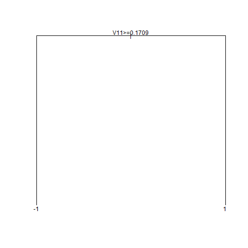

```r
plot(model2)
text(model2)
```

### Model 3 (Maximum branches)

Repeat the previous exercise for a tree of depth 6 by using *control=rpart.control(minsplit=0, minbucket=0, cp=-1,maxcompete=0, maxsurrogate=0, sesurrogate=0, xval=0,maxdepth=6)* .

Which model seems better?

```r
model3 =rpart(y~.,x,
control=rpart.control(minsplit=0,
minbucket=0,cp=-1,maxcompete=0,
maxsurrogate=0, usesurrogate=0, xval=0,maxdepth=6))
```

[Rpart controls](https://stat.ethz.ch/R-manual/R-patched/library/rpart/html/rpart.control.html)

### Model 3 (Maximum branches)

How good is this on training data ?

```r
model3TrainPreds = predict(model3,x,type="class")
percentageAccuracy(model3TrainPreds, y)
```

```
[1] 100
```

100% !!!

This was expected since we are putting everything into model creation and we are running test on training data.

### Model 3 (Maximum branches)

```r
model3TestPreds = predict(model3,x,type="class")
percentageAccuracy(model3TestPreds, y_test)
```

[output not shown]

It's hard to hit 100% accuracy.

### Model 3 (Maximum branches)

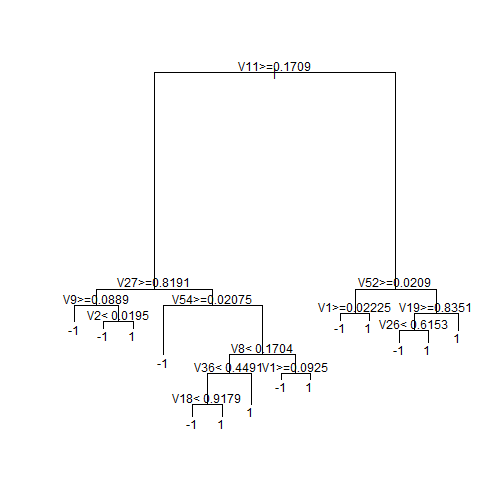

```r
plot(model3)
text(model3)
```

### Underfitting vs overfitting

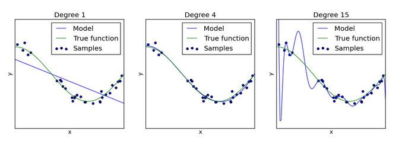

- [Read more](http://www.statsblogs.com/2014/03/20/machine-learning-lesson-of-the-day-overfitting-and-underfitting/)
- [Intuitive explanation of overfitting](http://quora.com/What-is-an-intuitive-explanation-of-overfitting)
- Scikit learn documentation, better explanation with python code [Decision trees](http://scikit-learn.org/stable/modules/tree.html)
- Underfitting and overfitting are better explained with regression models.

### Comparison

Percentage accuracy

[output not shown]

### How do we/R make these trees ?

Hunts Algorithm

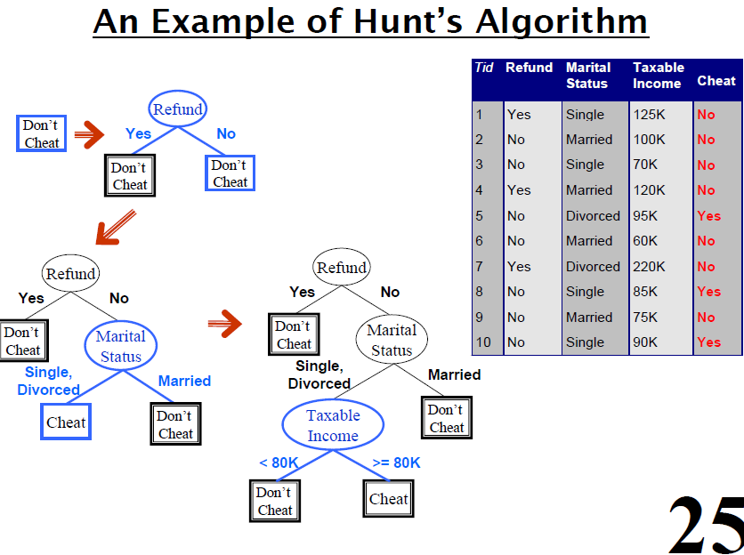

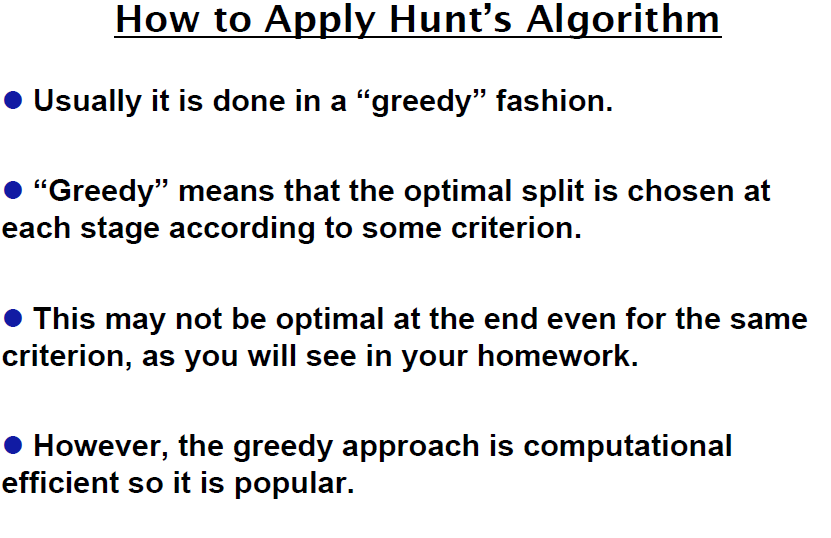

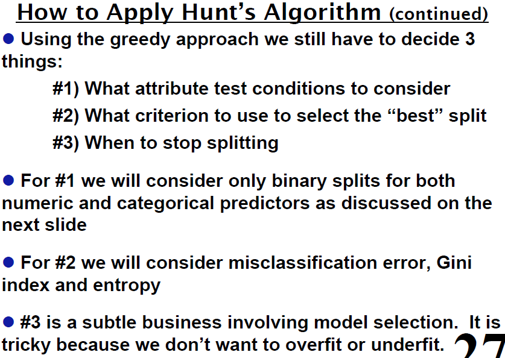

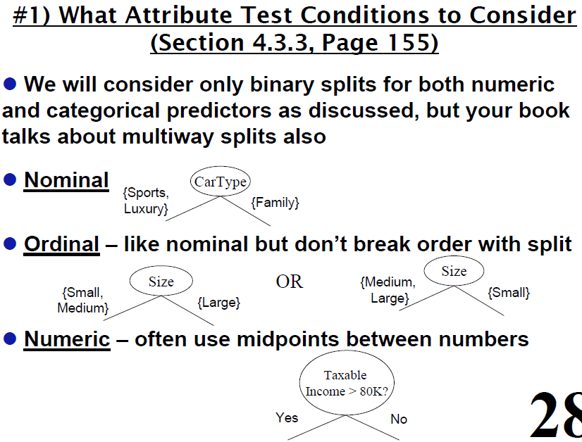

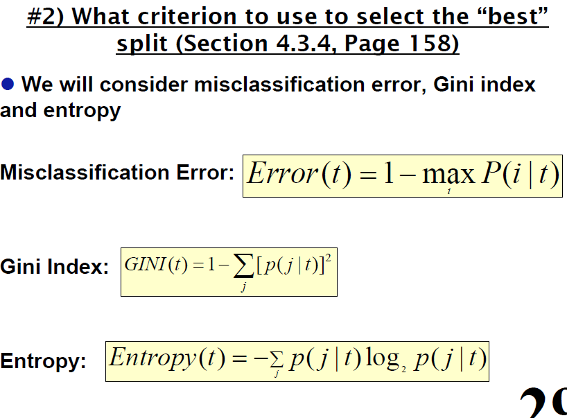

Here we have to find out the root node. Root node can be either A, B, or C.

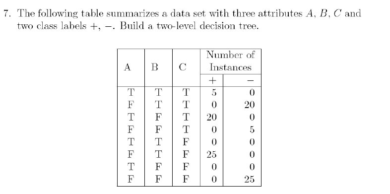

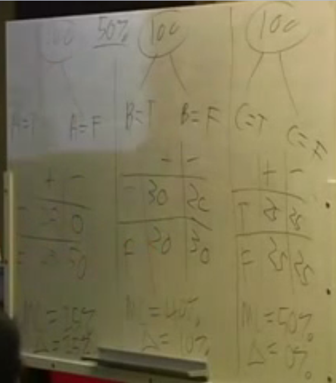

Sample calculation

- Misclasification is the simplest model.  
  `Misclassificaiotn = (1 - PercentageAccuracy)`
- Entropy is used by the [ID3](http://en.wikipedia.org/wiki/ID3_algorithm), [C4.5](http://en.wikipedia.org/wiki/C4.5_algorithm) and [C5.0] tree-generation algorithms using [Information gain](http://en.wikipedia.org/wiki/Information_gain_in_decision_trees) which is based on the concept of entropy.
- Gini index is used in CART and R packagae Rpart.

Read this [part of the book](http://www-users.cs.umn.edu/%7Ekumar/dmbook/ch4.pdf), it's easy maths.

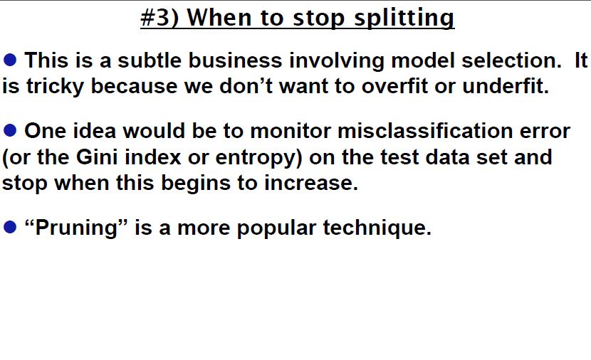

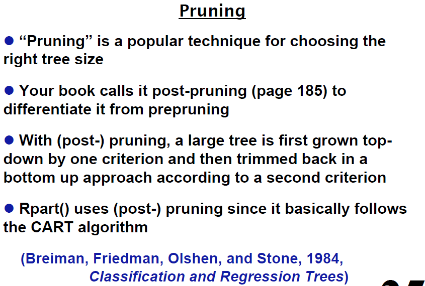

### thank you!

Courtesy

- Shamelesly copied form here and there + my examples. Mainly Stats 202.
- Created using Markdown + [Knitr](http://yihui.name/knitr/)